# Work Practices and Perceptions from Women Core Developers in OSS Communities

Edna Dias Canedo, Rodrigo Bonifácio, Márcio Okimoto, Alexander Serebrenik, Gustavo Pinto, and Eduardo Monteiro

## Script assessing the second research question

### (01) Laod the datasets

To answer RQ2, we use the following datasets.

- commits_female_categorized.csv: contains information about the contributions from the set WCD (women core developers)
- commits_male_s1_categorized.csv: contains information about the contributions from the set MCD1 (men core developers)
- commits_male_s2_categorized.csv: contains information about the contributions from the set MCD2 (men core developers)
- commits_male_s3_categorized.csv: contains information about the contributions from the set MCD3 (men core developers)

We first load these datasets, show some basic information, and perform some data cleanup.

```r
f_commits_ds <- read.csv("../datasets/commits_female_categorized.csv", head=T, sep=";")
colnames(f_commits_ds)
```

```
##  [1] "repo"              "user"              "login"
##  [4] "last_modified"     "hash_commit"       "num_files"
##  [7] "num_lines_changed" "num_lines_deleted" "num_lines_added"
## [10] "num_files_changed" "num_files_deleted" "num_files_added"
## [13] "num_files_renamed" "url_commit"        "message"
## [16] "class"
```

```r
nrow(f_commits_ds)
```

```
## [1] 22326
```

```r
f_commits_ds["commit_date"] <- as.character(as.Date(strptime((
   f_commits_ds$last_modified), "%a, %d %b %Y %H:%M:%S")))

f_commits_ds$gender <- "women"
f_commits_ds$genderGroup <- "WCD"

m_commits_s1_ds <- read.csv("../datasets/commits_male_s1_categorized.csv", head=T, sep=";")
colnames(m_commits_s1_ds)
```

```
##  [1] "repo"              "user"              "login"
##  [4] "last_modified"     "hash_commit"       "num_files"
##  [7] "num_lines_changed" "num_lines_deleted" "num_lines_added"
## [10] "num_files_changed" "num_files_deleted" "num_files_added"
## [13] "num_files_renamed" "url_commit"        "message"
## [16] "class"
```

```r
nrow(m_commits_s1_ds)
```

```
## [1] 33840
```

```r
m_commits_s1_ds["commit_date"] <- as.character(as.Date(strptime((
   m_commits_s1_ds$last_modified), "%a, %d %b %Y %H:%M:%S")))

m_commits_s1_ds$gender <- "men"
m_commits_s1_ds$genderGroup <- "MCD1"


m_commits_s2_ds <- read.csv("../datasets/commits_male_s2_categorized.csv", head=T, sep=";")
colnames(m_commits_s2_ds)
```

```
##  [1] "repo"              "user"              "login"
##  [4] "last_modified"     "hash_commit"       "num_files"
##  [7] "num_lines_changed" "num_lines_deleted" "num_lines_added"
## [10] "num_files_changed" "num_files_deleted" "num_files_added"
## [13] "num_files_renamed" "url_commit"        "message"
## [16] "class"
```

```r
nrow(m_commits_s2_ds)
```

```
## [1] 32818
```

```r
m_commits_s2_ds["commit_date"] <- as.character(as.Date(strptime((
   m_commits_s2_ds$last_modified), "%a, %d %b %Y %H:%M:%S")))

m_commits_s2_ds$gender <- "men"
m_commits_s2_ds$genderGroup <- "MCD2"


m_commits_s3_ds <- read.csv("../datasets/commits_male_s3_categorized.csv", head=T, sep=";")
colnames(m_commits_s3_ds)
```

```
##  [1] "repo"              "user"              "login"
##  [4] "last_modified"     "hash_commit"       "num_files"
##  [7] "num_lines_changed" "num_lines_deleted" "num_lines_added"
## [10] "num_files_changed" "num_files_deleted" "num_files_added"
## [13] "num_files_renamed" "url_commit"        "message"
## [16] "class"
```

```r
nrow(m_commits_s3_ds)
```

```
## [1] 50520
```

```r
m_commits_s3_ds["commit_date"] <- as.character(as.Date(strptime((
   m_commits_s3_ds$last_modified), "%a, %d %b %Y %H:%M:%S")))

m_commits_s3_ds$gender <- "men"
m_commits_s3_ds$genderGroup <- "MCD3"

commits_ds <- rbind(f_commits_ds, m_commits_s1_ds)
commits_ds <- rbind(commits_ds, m_commits_s2_ds)
commits_ds <- rbind(commits_ds, m_commits_s3_ds)

colnames(commits_ds)
```

```
##  [1] "repo"              "user"              "login"
##  [4] "last_modified"     "hash_commit"       "num_files"
##  [7] "num_lines_changed" "num_lines_deleted" "num_lines_added"
## [10] "num_files_changed" "num_files_deleted" "num_files_added"
## [13] "num_files_renamed" "url_commit"        "message"
## [16] "class"             "commit_date"       "gender"
## [19] "genderGroup"
```

```r
nrow(commits_ds)
```

```
## [1] 139504
```

```r
sqldf("select count (distinct(commit_date)) from commits_ds")
```

```
##   count (distinct(commit_date))
## 1                          2694
```

```r
head(commits_ds[,c("commit_date", "last_modified")])
```

```
##   commit_date                 last_modified
## 1  2018-06-13 Wed, 13 Jun 2018 13:07:49 GMT
## 2  2018-06-13 Wed, 13 Jun 2018 13:07:49 GMT
## 3  2018-06-13 Wed, 13 Jun 2018 13:07:49 GMT
## 4  2018-06-13 Wed, 13 Jun 2018 13:07:49 GMT
## 5  2018-06-13 Wed, 13 Jun 2018 13:07:49 GMT
## 6  2018-06-13 Wed, 13 Jun 2018 13:07:49 GMT
```

```r
sqldf("select count(distinct login) from f_commits_ds")
```

```
##   count(distinct login)
## 1                    36
```

```r
sqldf("select count(distinct login) from m_commits_s1_ds")
```

```
##   count(distinct login)
## 1                    37
```

```r
sqldf("select count(distinct login) from m_commits_s2_ds")
```

```
##   count(distinct login)
## 1                    37
```

```r
sqldf("select count(distinct login) from m_commits_s3_ds")
```

```
##   count(distinct login)
## 1                    37
```

```r
head(sqldf("select  login, count(*) from m_commits_s3_ds
       group by login order by 2 desc"))
```

```
##        login count(*)
## 1 login-1454    23582
## 2 login-1476     3043
## 3 login-1805     3021
## 4  login-281     2288
## 5  login-678     1767
## 6 login-2051     1545
```

```r
# remove an outilier contributor

commits_ds <- commits_ds[commits_ds$login != "michaelni",]

nrow(commits_ds)
```

```
## [1] 139504
```

```r
sqldf("select genderGroup, count(*)
       from commits_ds
      group by genderGroup")
```

```
##   genderGroup count(*)
## 1        MCD1    33840
## 2        MCD2    32818
## 3        MCD3    50520
## 4         WCD    22326
```

### (02) Summarizing our dataset

Let’s summarize our dataset by core developer, and also preserving his / her gender and gender group.

```r
commits_by_user <- sqldf("select login, gender, genderGroup,
                                 count(distinct hash_commit) commits,
                                 max(commit_date) max_date,
                                 min(commit_date) min_date,
                                 count(distinct commit_date) frequency,
                                 sum(num_files) files ,
                                 sum(num_files_changed) files_changed,
                                 sum(num_files_deleted) files_deleted,
                                 sum(num_files_added) files_added,
                                 sum(num_files_renamed) files_renamed,
                                 sum(num_lines_changed) lines_changed,
                                 sum(num_lines_deleted) lines_deleted,
                                 sum(num_lines_added) lines_added
                          from commits_ds
                          group by login, gender, genderGroup")


colnames(commits_by_user)
```

```
##  [1] "login"         "gender"        "genderGroup"   "commits"
##  [5] "max_date"      "min_date"      "frequency"     "files"
##  [9] "files_changed" "files_deleted" "files_added"   "files_renamed"
## [13] "lines_changed" "lines_deleted" "lines_added"
```

```r
nrow(commits_by_user)
```

```
## [1] 147
```

### (03) Hypothesis testing about the number of commits.

Now we can verify if there is any difference between these groups, in terms of total number of commits.

- First showing the boxplts

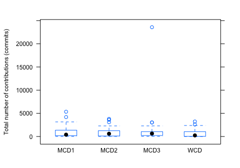

```r
bwplot(commits_by_user$commits~commits_by_user$genderGroup,
       ylab="Total number of contributions (commits)",
       par.settings = list(
                           axis.text = list(cex = 0.75),
                           par.xlab.text = list(cex = 0.75),
                           par.ylab.text = list(cex = 0.75)
                          ))
```

- Second performing a multicomparison test (using the Dunnett’s method)

```r
c<-nparcomp(commits~genderGroup, data=commits_by_user, asy.method = "logit",
            type = "Dunnett", control = "WCD", alternative = "two.sided", info = FALSE)

summary(c)
```

```
##
##  #------------Nonparametric Multiple Comparisons for relative contrast effects----------#
##
##  - Alternative Hypothesis:  True relative contrast effect p is not equal to 1/2
##  - Estimation Method: Global Pseudo ranks
##  - Type of Contrast : Dunnett
##  - Confidence Level: 95 %
##  - Method = Logit - Transformation
##
##  - Estimation Method: Pairwise rankings
##
##  #---------------------------Interpretation--------------------------------------------#
##  p(a,b) > 1/2 : b tends to be larger than a
##  #-------------------------------------------------------------------------------------#
##
##  #----Data Info-------------------------------------------------------------------------#
##   Sample Size
## 1   MCD1   37
## 2   MCD2   37
## 3   MCD3   37
## 4    WCD   36
##
##  #----Contrast--------------------------------------------------------------------------#
##            MCD1 MCD2 MCD3 WCD
## MCD1 - WCD    1    0    0  -1
## MCD2 - WCD    0    1    0  -1
## MCD3 - WCD    0    0    1  -1
##
##  #----Analysis--------------------------------------------------------------------------#
##        Comparison Estimator Lower Upper Statistic   p.Value
## 1 p( WCD , MCD1 )     0.607 0.446 0.749  1.552297 0.2640440
## 2 p( WCD , MCD2 )     0.593 0.431 0.737  1.338565 0.3762799
## 3 p( WCD , MCD3 )     0.617 0.453 0.759  1.671308 0.2125555
##
##  #----Overall---------------------------------------------------------------------------#
##   Quantile   p.Value
## 1 2.329063 0.2125555
##
##  #--------------------------------------------------------------------------------------#
```

### (04) Hypothesis testing about the frequency of commits.

Now we can verify if there is any difference between these groups, in terms of frequency of commits.

- First computing the metrics and showing the boxplts

```r
commits_by_user["date_diff"] = as.numeric(difftime(as.Date(commits_by_user$max_date),
                                                   as.Date(commits_by_user$min_date), units="days"))

commits_by_user["frequency2"] = 100*commits_by_user$frequency / commits_by_user$date_diff

cor.test(commits_by_user$frequency2, commits_by_user$commits, method="spearman")
```

```
##
##  Spearman's rank correlation rho
##
## data:  commits_by_user$frequency2 and commits_by_user$commits
## S = 454549, p-value = 0.08762
## alternative hypothesis: true rho is not equal to 0
## sample estimates:
##       rho
## 0.1413813
```

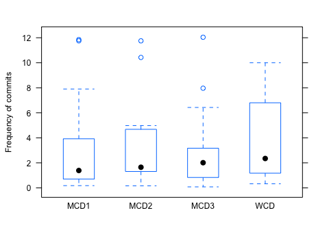

```r
bwplot(commits_by_user$frequency2~commits_by_user$genderGroup, ylab="Frequency of commits",
       par.settings = list(
                           axis.text = list(cex = 0.75),
                           par.xlab.text = list(cex = 0.75),
                           par.ylab.text = list(cex = 0.75)
                          ))
```

- Second computing the summary of the observations

```r
summary(commits_by_user[commits_by_user$gender == 'women',]$frequency2)
```

```
##    Min. 1st Qu.  Median    Mean 3rd Qu.    Max.
##  0.3264  1.1860  2.3479     Inf  6.2410     Inf
```

```r
summary(commits_by_user[commits_by_user$gender == 'men',]$frequency2)
```

```
##    Min. 1st Qu.  Median    Mean 3rd Qu.    Max.
## 0.07949 0.93655 1.91943     Inf 3.68800     Inf
```

```r
summary(commits_by_user[commits_by_user$genderGroup == 'WCD',]$frequency2)
```

```
##    Min. 1st Qu.  Median    Mean 3rd Qu.    Max.
##  0.3264  1.1860  2.3479     Inf  6.2410     Inf
```

```r
summary(commits_by_user[commits_by_user$genderGroup == 'MCD1',]$frequency2)
```

```
##    Min. 1st Qu.  Median    Mean 3rd Qu.    Max.
##  0.1781  0.7025  1.3871     Inf  3.9216     Inf
```

```r
summary(commits_by_user[commits_by_user$genderGroup == 'MCD2',]$frequency2)
```

```
##    Min. 1st Qu.  Median    Mean 3rd Qu.    Max.
##  0.1621  1.3100  1.6484     Inf  4.6809     Inf
```

```r
summary(commits_by_user[commits_by_user$genderGroup == 'MCD3',]$frequency2)
```

```
##    Min. 1st Qu.  Median    Mean 3rd Qu.    Max.
## 0.07949 0.83160 2.01149     Inf 3.16901     Inf
```

- Third performing a multicomparison test (using the Dunnett’s method)

```r
c<-nparcomp(frequency2~genderGroup, data=commits_by_user, asy.method = "probit",
            type = "Dunnett", control = "WCD", alternative = "two.sided", info = FALSE)


summary(c)
```

```
##
##  #------------Nonparametric Multiple Comparisons for relative contrast effects----------#
##
##  - Alternative Hypothesis:  True relative contrast effect p is not equal to 1/2
##  - Estimation Method: Global Pseudo ranks
##  - Type of Contrast : Dunnett
##  - Confidence Level: 95 %
##  - Method = Probit - Transformation
##
##  - Estimation Method: Pairwise rankings
##
##  #---------------------------Interpretation--------------------------------------------#
##  p(a,b) > 1/2 : b tends to be larger than a
##  #-------------------------------------------------------------------------------------#
##
##  #----Data Info-------------------------------------------------------------------------#
##   Sample Size
## 1   MCD1   37
## 2   MCD2   37
## 3   MCD3   37
## 4    WCD   36
##
##  #----Contrast--------------------------------------------------------------------------#
##            MCD1 MCD2 MCD3 WCD
## MCD1 - WCD    1    0    0  -1
## MCD2 - WCD    0    1    0  -1
## MCD3 - WCD    0    0    1  -1
##
##  #----Analysis--------------------------------------------------------------------------#
##        Comparison Estimator Lower Upper  Statistic   p.Value
## 1 p( WCD , MCD1 )     0.401 0.256 0.561 -1.4491658 0.3244631
## 2 p( WCD , MCD2 )     0.474 0.319 0.634 -0.3698101 0.9648048
## 3 p( WCD , MCD3 )     0.414 0.266 0.577 -1.2345008 0.4518341
##
##  #----Overall---------------------------------------------------------------------------#
##   Quantile   p.Value
## 1 2.340624 0.3244631
##
##  #--------------------------------------------------------------------------------------#
```

### (05) Hypothesis testing about the size of the contributions

#### 5.1 Considering lines of code

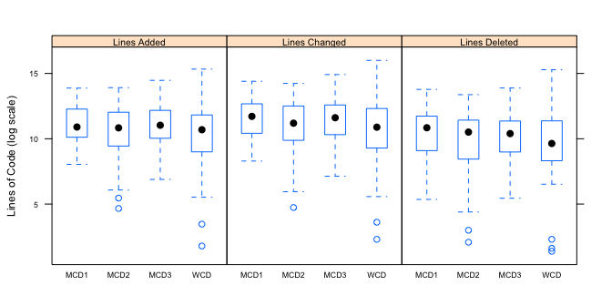

```r
lines <- commits_by_user[,c("login", "gender", "genderGroup",
                            "lines_added", "lines_changed", "lines_deleted")]

lines <- melt(lines, id.vars = c("login", "gender", "genderGroup"))

lines <- lines[order(lines$variable),]

lines$variable <- gsub("lines_added", "Lines Added", lines$variable)
lines$variable <- gsub("lines_changed", "Lines Changed", lines$variable)
lines$variable <- gsub("lines_deleted", "Lines Deleted", lines$variable)


bwplot(log(value)~genderGroup|variable, data=lines,
       ylab="Lines of Code (log scale)", layout=c(3,1),
       par.settings = list(
                           axis.text = list(cex = 0.55),
                           par.xlab.text = list(cex = 0.75),
                           par.ylab.text = list(cex = 0.75)
                          ),
       par.strip.text = list(cex = 0.65))
```

```r
la <- lines[lines$variable == "Lines Added", ]
lc <- lines[lines$variable == "Lines Changed", ]
ld <- lines[lines$variable == "Lines Deleted", ]


c<-nparcomp(value~genderGroup, data=la, asy.method = "probit",
            type = "Dunnett", control = "WCD", alternative = "two.sided", info = FALSE)

summary(c)
```

```
##
##  #------------Nonparametric Multiple Comparisons for relative contrast effects----------#
##
##  - Alternative Hypothesis:  True relative contrast effect p is not equal to 1/2
##  - Estimation Method: Global Pseudo ranks
##  - Type of Contrast : Dunnett
##  - Confidence Level: 95 %
##  - Method = Probit - Transformation
##
##  - Estimation Method: Pairwise rankings
##
##  #---------------------------Interpretation--------------------------------------------#
##  p(a,b) > 1/2 : b tends to be larger than a
##  #-------------------------------------------------------------------------------------#
##
##  #----Data Info-------------------------------------------------------------------------#
##   Sample Size
## 1   MCD1   37
## 2   MCD2   37
## 3   MCD3   37
## 4    WCD   36
##
##  #----Contrast--------------------------------------------------------------------------#
##            MCD1 MCD2 MCD3 WCD
## MCD1 - WCD    1    0    0  -1
## MCD2 - WCD    0    1    0  -1
## MCD3 - WCD    0    0    1  -1
##
##  #----Analysis--------------------------------------------------------------------------#
##        Comparison Estimator Lower Upper Statistic   p.Value
## 1 p( WCD , MCD1 )     0.583 0.423 0.731  1.212052 0.4548594
## 2 p( WCD , MCD2 )     0.521 0.363 0.675  0.305700 0.9779127
## 3 p( WCD , MCD3 )     0.588 0.427 0.735  1.275836 0.4145653
##
##  #----Overall---------------------------------------------------------------------------#
##   Quantile   p.Value
## 1 2.330549 0.4145653
##
##  #--------------------------------------------------------------------------------------#
```

```r
c<-nparcomp(value~genderGroup, data=lc, asy.method = "probit",
            type = "Dunnett", control = "WCD", alternative = "two.sided", info = FALSE)


summary(c)
```

```
##
##  #------------Nonparametric Multiple Comparisons for relative contrast effects----------#
##
##  - Alternative Hypothesis:  True relative contrast effect p is not equal to 1/2
##  - Estimation Method: Global Pseudo ranks
##  - Type of Contrast : Dunnett
##  - Confidence Level: 95 %
##  - Method = Probit - Transformation
##
##  - Estimation Method: Pairwise rankings
##
##  #---------------------------Interpretation--------------------------------------------#
##  p(a,b) > 1/2 : b tends to be larger than a
##  #-------------------------------------------------------------------------------------#
##
##  #----Data Info-------------------------------------------------------------------------#
##   Sample Size
## 1   MCD1   37
## 2   MCD2   37
## 3   MCD3   37
## 4    WCD   36
##
##  #----Contrast--------------------------------------------------------------------------#
##            MCD1 MCD2 MCD3 WCD
## MCD1 - WCD    1    0    0  -1
## MCD2 - WCD    0    1    0  -1
## MCD3 - WCD    0    0    1  -1
##
##  #----Analysis--------------------------------------------------------------------------#
##        Comparison Estimator Lower Upper Statistic   p.Value
## 1 p( WCD , MCD1 )     0.599 0.439 0.744 1.4503127 0.3196530
## 2 p( WCD , MCD2 )     0.539 0.380 0.692 0.5671803 0.8866627
## 3 p( WCD , MCD3 )     0.583 0.423 0.731 1.2114512 0.4613461
##
##  #----Overall---------------------------------------------------------------------------#
##   Quantile  p.Value
## 1 2.335123 0.319653
##
##  #--------------------------------------------------------------------------------------#
```

```r
c<-nparcomp(value~genderGroup, data=ld, asy.method = "probit",
            type = "Dunnett", control = "WCD", alternative = "two.sided", info = FALSE)


summary(c)
```

```
##
##  #------------Nonparametric Multiple Comparisons for relative contrast effects----------#
##
##  - Alternative Hypothesis:  True relative contrast effect p is not equal to 1/2
##  - Estimation Method: Global Pseudo ranks
##  - Type of Contrast : Dunnett
##  - Confidence Level: 95 %
##  - Method = Probit - Transformation
##
##  - Estimation Method: Pairwise rankings
##
##  #---------------------------Interpretation--------------------------------------------#
##  p(a,b) > 1/2 : b tends to be larger than a
##  #-------------------------------------------------------------------------------------#
##
##  #----Data Info-------------------------------------------------------------------------#
##   Sample Size
## 1   MCD1   37
## 2   MCD2   37
## 3   MCD3   37
## 4    WCD   36
##
##  #----Contrast--------------------------------------------------------------------------#
##            MCD1 MCD2 MCD3 WCD
## MCD1 - WCD    1    0    0  -1
## MCD2 - WCD    0    1    0  -1
## MCD3 - WCD    0    0    1  -1
##
##  #----Analysis--------------------------------------------------------------------------#
##        Comparison Estimator Lower Upper Statistic   p.Value
## 1 p( WCD , MCD1 )     0.603 0.442 0.747 1.5049903 0.2989785
## 2 p( WCD , MCD2 )     0.538 0.379 0.692 0.5555088 0.8981476
## 3 p( WCD , MCD3 )     0.584 0.423 0.732 1.2239932 0.4638206
##
##  #----Overall---------------------------------------------------------------------------#
##   Quantile   p.Value
## 1 2.341695 0.2989785
##
##  #--------------------------------------------------------------------------------------#
```

#### 5.2 Considering number of files

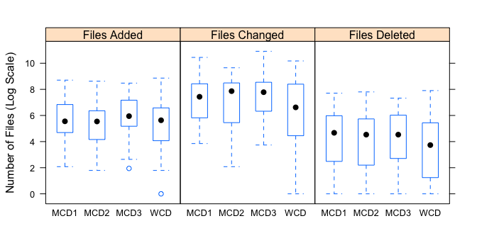

```r
files <- commits_by_user[,c("login", "gender", "genderGroup",
                            "files_added", "files_changed", "files_deleted")]

files <- melt(files, id.vars = c("login", "gender", "genderGroup"))

files <- files[order(files$variable),]

files$variable <- gsub("files_added", "Files Added", files$variable)
files$variable <- gsub("files_changed", "Files Changed", files$variable)
files$variable <- gsub("files_deleted", "Files Deleted", files$variable)


bwplot(log(value)~genderGroup|variable, data=files,ylab="Number of Files (Log Scale)",layout=c(3,1))
```

```r
fa <- files[files$variable == "Files Added", ]
fc <- files[files$variable == "Files Changed", ]
fd <- files[files$variable == "Files Deleted", ]

c<-nparcomp(value~genderGroup, data=fa, asy.method = "probit",
            type = "Dunnett", control = "WCD", alternative = "two.sided", info = FALSE)


summary(c)
```

```
##
##  #------------Nonparametric Multiple Comparisons for relative contrast effects----------#
##
##  - Alternative Hypothesis:  True relative contrast effect p is not equal to 1/2
##  - Estimation Method: Global Pseudo ranks
##  - Type of Contrast : Dunnett
##  - Confidence Level: 95 %
##  - Method = Probit - Transformation
##
##  - Estimation Method: Pairwise rankings
##
##  #---------------------------Interpretation--------------------------------------------#
##  p(a,b) > 1/2 : b tends to be larger than a
##  #-------------------------------------------------------------------------------------#
##
##  #----Data Info-------------------------------------------------------------------------#
##   Sample Size
## 1   MCD1   37
## 2   MCD2   37
## 3   MCD3   37
## 4    WCD   36
##
##  #----Contrast--------------------------------------------------------------------------#
##            MCD1 MCD2 MCD3 WCD
## MCD1 - WCD    1    0    0  -1
## MCD2 - WCD    0    1    0  -1
## MCD3 - WCD    0    0    1  -1
##
##  #----Analysis--------------------------------------------------------------------------#
##        Comparison Estimator Lower Upper  Statistic   p.Value
## 1 p( WCD , MCD1 )     0.535 0.375 0.689  0.4980299 0.9161155
## 2 p( WCD , MCD2 )     0.477 0.322 0.635 -0.3378949 0.9707357
## 3 p( WCD , MCD3 )     0.549 0.389 0.701  0.7069528 0.8022495
##
##  #----Overall---------------------------------------------------------------------------#
##   Quantile   p.Value
## 1 2.331778 0.8022495
##
##  #--------------------------------------------------------------------------------------#
```

```r
c<-nparcomp(value~genderGroup, data=fc, asy.method = "probit",
            type = "Dunnett", control = "WCD", alternative = "two.sided", info = FALSE)


summary(c)
```

```
##
##  #------------Nonparametric Multiple Comparisons for relative contrast effects----------#
##
##  - Alternative Hypothesis:  True relative contrast effect p is not equal to 1/2
##  - Estimation Method: Global Pseudo ranks
##  - Type of Contrast : Dunnett
##  - Confidence Level: 95 %
##  - Method = Probit - Transformation
##
##  - Estimation Method: Pairwise rankings
##
##  #---------------------------Interpretation--------------------------------------------#
##  p(a,b) > 1/2 : b tends to be larger than a
##  #-------------------------------------------------------------------------------------#
##
##  #----Data Info-------------------------------------------------------------------------#
##   Sample Size
## 1   MCD1   37
## 2   MCD2   37
## 3   MCD3   37
## 4    WCD   36
##
##  #----Contrast--------------------------------------------------------------------------#
##            MCD1 MCD2 MCD3 WCD
## MCD1 - WCD    1    0    0  -1
## MCD2 - WCD    0    1    0  -1
## MCD3 - WCD    0    0    1  -1
##
##  #----Analysis--------------------------------------------------------------------------#
##        Comparison Estimator Lower Upper Statistic   p.Value
## 1 p( WCD , MCD1 )     0.578 0.417 0.727 1.1293498 0.5093193
## 2 p( WCD , MCD2 )     0.565 0.405 0.715 0.9498583 0.6349706
## 3 p( WCD , MCD3 )     0.611 0.450 0.755 1.6174145 0.2352283
##
##  #----Overall---------------------------------------------------------------------------#
##   Quantile   p.Value
## 1 2.331034 0.2352283
##
##  #--------------------------------------------------------------------------------------#
```

```r
c<-nparcomp(value~genderGroup, data=fd, asy.method = "probit",
            type = "Dunnett", control = "WCD", alternative = "two.sided", info = FALSE)


summary(c)
```

```
##
##  #------------Nonparametric Multiple Comparisons for relative contrast effects----------#
##
##  - Alternative Hypothesis:  True relative contrast effect p is not equal to 1/2
##  - Estimation Method: Global Pseudo ranks
##  - Type of Contrast : Dunnett
##  - Confidence Level: 95 %
##  - Method = Probit - Transformation
##
##  - Estimation Method: Pairwise rankings
##
##  #---------------------------Interpretation--------------------------------------------#
##  p(a,b) > 1/2 : b tends to be larger than a
##  #-------------------------------------------------------------------------------------#
##
##  #----Data Info-------------------------------------------------------------------------#
##   Sample Size
## 1   MCD1   37
## 2   MCD2   37
## 3   MCD3   37
## 4    WCD   36
##
##  #----Contrast--------------------------------------------------------------------------#
##            MCD1 MCD2 MCD3 WCD
## MCD1 - WCD    1    0    0  -1
## MCD2 - WCD    0    1    0  -1
## MCD3 - WCD    0    0    1  -1
##
##  #----Analysis--------------------------------------------------------------------------#
##        Comparison Estimator Lower Upper Statistic   p.Value
## 1 p( WCD , MCD1 )     0.560 0.400 0.712 0.8792661 0.7106625
## 2 p( WCD , MCD2 )     0.533 0.373 0.687 0.4747208 0.9353574
## 3 p( WCD , MCD3 )     0.554 0.393 0.706 0.7810890 0.7761570
##
##  #----Overall---------------------------------------------------------------------------#
##   Quantile   p.Value
## 1 2.351093 0.7106625
##
##  #--------------------------------------------------------------------------------------#
```

### (06) Hypothesis testing about the type of the contributions

- First, lets investigate the size of the comments in the commits.

```r
commits_ds["comment_size"] = nchar(as.character(commits_ds$message))

# boxplot(log(commits_ds$comment_size)~commits_ds$genderGroup)

wilcox.test(comment_size~gender, data = commits_ds)
```

```
##
##  Wilcoxon rank sum test with continuity correction
##
## data:  comment_size by gender
## W = 1.374e+09, p-value < 2.2e-16
## alternative hypothesis: true location shift is not equal to 0
```

- Second, lets investigate the type of the contributions.

There is some differences in the number of commits from the groups WCD, MCD1, MCD2, and MCD3. Therefore, we first balance the dataset.

```r
set.seed(5)

m_commits_s1_ds <- m_commits_s1_ds[sample(nrow(m_commits_s1_ds), 22326, replace = FALSE, prob = NULL),]

m_commits_s2_ds <- m_commits_s2_ds[sample(nrow(m_commits_s2_ds), 22326, replace = FALSE, prob = NULL),]

m_commits_s3_ds <- m_commits_s3_ds[sample(nrow(m_commits_s3_ds), 22326, replace = FALSE, prob = NULL),]

nrow(f_commits_ds)
```

```
## [1] 22326
```

```r
nrow(m_commits_s1_ds)
```

```
## [1] 22326
```

```r
nrow(m_commits_s2_ds)
```

```
## [1] 22326
```

```r
nrow(m_commits_s3_ds)
```

```
## [1] 22326
```

```r
commits_ds <- rbind(f_commits_ds, m_commits_s1_ds)
commits_ds <- rbind(commits_ds, m_commits_s2_ds)
commits_ds <- rbind(commits_ds, m_commits_s3_ds)
```

And now we execute the analysis using a balanced dataset.

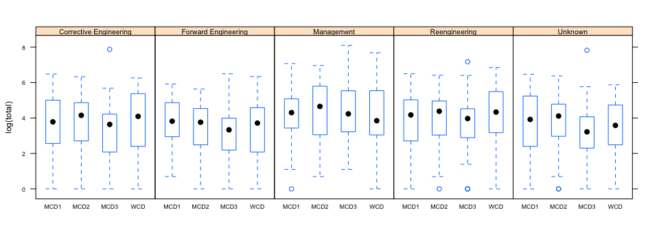

```r
contributions_ds <- sqldf("select login, gender, genderGroup, class, count(*) total
                           from commits_ds
                           group by login, gender, genderGroup, class")


bwplot(log(total)~genderGroup|class, data=contributions_ds,  par.settings = list(
                               axis.text = list(cex = 0.55),
                               par.xlab.text = list(cex = 0.75),
                               par.ylab.text = list(cex = 0.75)
                          ),  par.strip.text = list(cex = 0.65), layout=c(5,1))
```

```r
prop.table(table(commits_ds$class, commits_ds$genderGroup), 1)
```

```
##
##                               MCD1      MCD2      MCD3       WCD
##   Corrective Engineering 0.2423249 0.2450672 0.2934921 0.2191158
##   Forward Engineering    0.2909000 0.2425659 0.2195922 0.2469418
##   Management             0.2117789 0.2671104 0.2438483 0.2772623
##   Reengineering          0.2479194 0.2294770 0.2215144 0.3010891
##   Unknown                0.3084063 0.2525855 0.2760541 0.1629541
```

```r
chisq.test(commits_ds$class, commits_ds$genderGroup)
```

```
##
##  Pearson's Chi-squared test
##
## data:  commits_ds$class and commits_ds$genderGroup
## X-squared = 1587.7, df = 12, p-value < 2.2e-16
```

1. Comparing the groups WCD and MCD1

```r
commits_ds <- rbind(f_commits_ds, m_commits_s1_ds)
prop.table(table(commits_ds$class, commits_ds$gender), 1)
```

```
##
##                                men     women
##   Corrective Engineering 0.5251486 0.4748514
##   Forward Engineering    0.5408654 0.4591346
##   Management             0.4330492 0.5669508
##   Reengineering          0.4515767 0.5484233
##   Unknown                0.6542897 0.3457103
```

```r
chisq.test(commits_ds$class, commits_ds$gender)
```

```
##
##  Pearson's Chi-squared test
##
## data:  commits_ds$class and commits_ds$gender
## X-squared = 1091.7, df = 4, p-value < 2.2e-16
```

2. Comparing the groups WCD and MCD2

```r
commits_ds <- rbind(f_commits_ds, m_commits_s2_ds)
prop.table(table(commits_ds$class, commits_ds$gender), 1)
```

```
##
##                                men     women
##   Corrective Engineering 0.5279539 0.4720461
##   Forward Engineering    0.4955303 0.5044697
##   Management             0.4906756 0.5093244
##   Reengineering          0.4325136 0.5674864
##   Unknown                0.6078494 0.3921506
```

```r
chisq.test(commits_ds$class, commits_ds$gender)
```

```
##
##  Pearson's Chi-squared test
##
## data:  commits_ds$class and commits_ds$gender
## X-squared = 507.49, df = 4, p-value < 2.2e-16
```

3. Comparing the groups WCD and MCD3

```r
commits_ds <- rbind(f_commits_ds, m_commits_s3_ds)
prop.table(table(commits_ds$class, commits_ds$gender), 1)
```

```
##
##                                men     women
##   Corrective Engineering 0.5725470 0.4274530
##   Forward Engineering    0.4706886 0.5293114
##   Management             0.4679396 0.5320604
##   Reengineering          0.4238671 0.5761329
##   Unknown                0.6288130 0.3711870
```

```r
chisq.test(commits_ds$class, commits_ds$gender)
```

```
##
##  Pearson's Chi-squared test
##
## data:  commits_ds$class and commits_ds$gender
## X-squared = 916.57, df = 4, p-value < 2.2e-16
```